# PBMC Single-Cell RNA Sequencing Data Analysis Pipeline

2025-02-13

# Project Name: PBMC Single-Cell RNA Sequencing Data Analysis Pipeline

## Part 1: Data Load

### Project Description

This project provides a comprehensive pipeline for analyzing single-cell RNA sequencing data, covering data loading, quality control, normalization, and preliminary visualization. The code utilizes the Seurat package, a widely used R package for single-cell RNA sequencing data analysis.

### Code Structure

- **Data Loading**: Load the PBMC (Peripheral Blood Mononuclear Cells) dataset from a specified directory.
- **Quality Control**: Filter cells by calculating the percentage of mitochondrial genes and RNA feature counts.
- **Data Normalization**: Normalize the data using the LogNormalize method.
- **Visualization**: Generate violin plots and feature scatter plots to visually assess data quality.

### Usage Instructions

1. Ensure the Seurat package is installed. If not, install it using the following command:

   ```r
   install.packages("Seurat")
   ```

2. Place the PBMC dataset in the `pbmc_1k` folder within the project directory.
3. Run the provided R script. The code will automatically load the data, perform quality control and normalization, and generate corresponding plots.

### Code Example

```
## Attaching SeuratObject
```

[output not shown]

[output not shown]

[output not shown]

[output not shown]

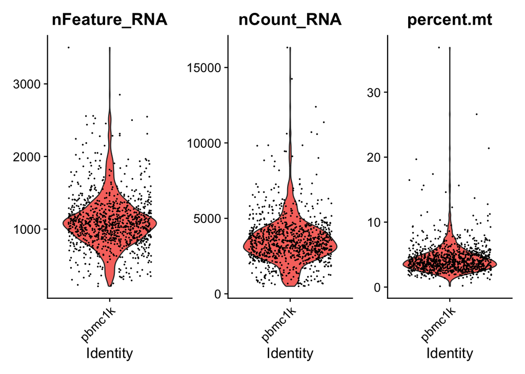

```r
# Load the PBMC dataset
pbmc.data <- Read10X(data.dir = "~/Desktop/papernew/new_method/code/pbmc_1k")
pbmc <- CreateSeuratObject(counts = pbmc.data, project = "pbmc1k", min.cells = 3, min.features = 200)

# Calculate the percentage of mitochondrial genes
pbmc[["percent.mt"]] <- PercentageFeatureSet(pbmc, pattern = "^MT-")

# Visualize quality control metrics
VlnPlot(pbmc, features = c("nFeature_RNA", "nCount_RNA", "percent.mt"), ncol = 3)
```

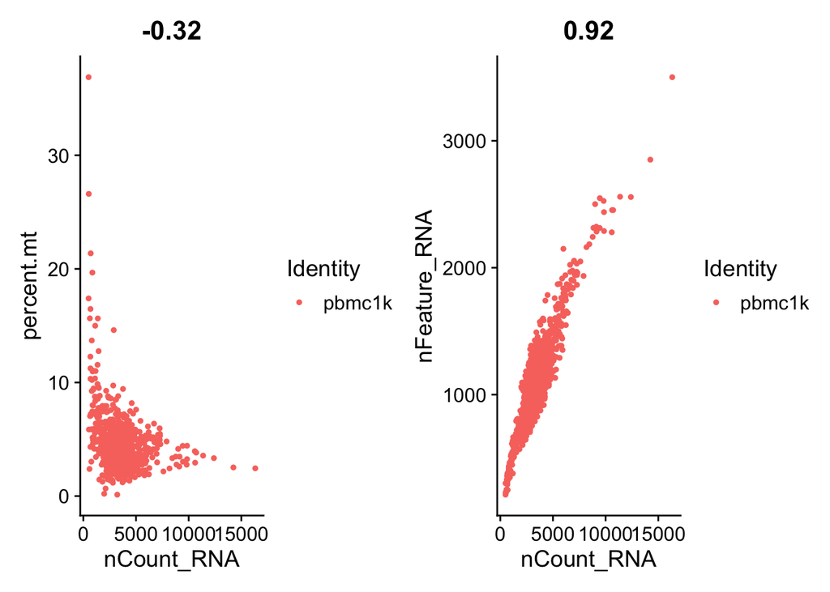

```r
# Generate feature scatter plots
plot1 <- FeatureScatter(pbmc, feature1 = "nCount_RNA", feature2 = "percent.mt")
plot2 <- FeatureScatter(pbmc, feature1 = "nCount_RNA", feature2 = "nFeature_RNA")
plot1 + plot2
```

```r
# Apply quality control filtering, min and max comes from VlnPlot
pbmc <- subset(pbmc, subset = nFeature_RNA > 200 & nFeature_RNA < 3000 & percent.mt < 5)

# Normalize the data
pbmc <- NormalizeData(pbmc, normalization.method = "LogNormalize", scale.factor = 10000)

# Prepare the data matrix for wavelet analysis
for_wavelet <- pbmc@assays$RNA$data
working_matrix <- as.matrix(for_wavelet)
```

## Part 2: Wavelet Analysis

### Overview

This R script defines a function `wavelet_transform` that performs wavelet transformations on an input matrix. The function supports three types of wavelet transforms: `2-band`, `3-band`, and `4-band`.

### Function: `wavelet_transform`

#### Arguments

- `input_matrix`: A matrix on which the wavelet transformation will be performed.
- `wavelet_type`: A string specifying the type of wavelet transform. Supported values are:
  - `"2-band"`: 2-band wavelet transform.
  - `"3-band"`: 3-band wavelet transform.
  - `"4-band"`: 4-band wavelet transform.

#### Functionality

1. **2-band Wavelet Transform**:
   - Calls the `two_band` function.
2. **3-band Wavelet Transform**:
   - Calls the `three_band` function.
3. **4-band Wavelet Transform**:
   - Calls the `four_band` function.
4. **Error Handling**:
   - If an unsupported `wavelet_type` is provided, the function stops and returns an error message.

#### Return Value

- The function returns the result of the wavelet transformation, which is typically a transformed matrix or a list of coefficients.

#### Example Usage

```r
result_2band <- wavelet_transform(working_matrix, wavelet_type = "2-band")
### 2-band low frequency data first 6 rows
```

[output not shown]

#### Notes

- Ensure that the `two_band`, `three_band`, and `four_band` functions are defined and available in your R environment.
- In our project we conduct the first level of wavelet transform, and thus the input matrix dimension should be compatible with the M-band wavelet transform. Otherwise, a few zero rows are automatically added corresponding to the number of bands.

#### Dependencies

- This function does not rely on external packages but assumes the existence of helper functions (`two_band`, `three_band`, and `four_band`).

## Part 3: Single-Cell RNA-Seq Analysis Pipeline

### Overview

This R script provides a pipeline for analyzing single-cell RNA sequencing (scRNA-seq) data. It includes functions for preprocessing, clustering, marker gene identification, and cell type annotation. The pipeline is designed to work with Seurat objects and integrates with external tools like `scCATCH` for cell type identification.

### Functions

#### 1. `main_function`

##### Description

This function performs a comprehensive analysis of scRNA-seq data, including normalization, dimensionality reduction, clustering, and marker gene identification.

##### Arguments

- `data_`: A matrix containing the raw gene expression data.
- `ob`: A Seurat object to store the processed data.
- `X`: A reference matrix used to set the row and column names of `data_`.
- `t1`, `t2`: Optional parameters for naming output files (currently commented out).

##### Workflow

1. **Data Preprocessing**:
   - Converts the input matrix into a sparse matrix format.
   - Updates the Seurat object with the processed data.
   - Identifies highly variable genes.
2. **Visualization**:
   - Plots the top 10 variable genes.
   - Scales the data and performs PCA.
3. **Dimensionality Reduction**:
   - Visualizes PCA loadings and performs JackStraw analysis to determine significant principal components.
   - Computes UMAP for visualization.
4. **Clustering**:
   - Identifies clusters using the `FindNeighbors` and `FindClusters` functions.
   - Finds marker genes for each cluster.
5. **Output**:
   - Returns a list containing the processed Seurat object (`data`) and marker genes (`markers`).

##### Example Usage

```r
two_band_low<-main_function(result_2band$low,pbmc,working_matrix,'2band','low')
```

```
## When using repel, set xnudge and ynudge to 0 for optimal results
```

```
## PC_ 1
## Positive:  CST3, S100A9, CSTA, FCN1, OLFM1, LGALS1, TYROBP, LYZ, CST7, S100A11
##     MS4A4A, FCER1G, S100A8, CD86, AC020656.1, TOMM40L, ODF3B, YEATS4, TYMP, NCR3
##     RXRA, SERPINA1, MNDA, DICER1, AIF1, S100A12, S100A5, GSAP, CTSK, PSAP
## Negative:  TNF, RPS29, AP003352.1, LRR1, CD3D, RPS6, AL391834.1, TRAC, GDPD5, RPS27
##     AC243965.1, ZNF584, LMLN, RPS18, RPS12, TRBC2, TRBC1, ALKBH6, ZC3H10, EPHB6
##     ST5, MPZ, B3GALT4, RAB34, IL32, CD79A, NOSIP, CD3G, MMP25-AS1, TBC1D8
## PC_ 2
## Positive:  NKG7, CTSW, GNLY, GZMB, GZMH, TRDC, CCL3, GZMA, CLDND2, SPON2
##     PRF1, GZMM, A2M-AS1, CTBP1-AS, GZMK, CD7, APMAP, CLIC3, IFITM2, AC132872.1
##     RNF212, S1PR5, CMC1, CCL5, EOMES, KLRB1, KLRD1, EIF4EBP2, SAMD3, TRAV25
## Negative:  HLA-DRB5, HLA-DRA, IGHD, HLA-DQA1, IGHM, FAM30A, HLA-DRB1, HLA-DQA2, CD74, HLA-DPA1
##     MS4A1, HLA-DQB1, HLA-DPB1, SIGLEC10, TCOF1, HLA-DMB, TCL1A, CD79B, FCRLA, BANK1
##     NCF1, TCL1B, FCER2, LINC00926, MARCH1, IGKC, TMEM40, HLA-DMA, IGHG1, AL139020.1
## PC_ 3
## Positive:  CD79B, IGHD, FAM30A, IGHM, HLA-DQA2, HLA-DQA1, MS4A1, HLA-DQB1, HLA-DPB1, HLA-DPA1
##     HLA-DRB1, CD74, TCL1A, HLA-DRB5, HLA-DOA, TCOF1, TCL1B, BANK1, AC062029.1, FCER2
##     IGHG1, HLA-DRA, IGKC, CD37, HLA-DMA, LINC00926, SLC6A16, CD24, HLA-DMB, IGHG3
## Negative:  CD3D, TRAC, IL7R, LDHB, AC243965.1, CD3G, RPL34, NOSIP, PRRG2, VIM
##     LEF1, S100A5, OSTC, CD5, IL32, GIMAP7, CD6, S100A10, RPS12, S100A6
##     ERN1, SPEF2, TRPM4, VCAN, ZNF213-AS1, S100A8, MMP25-AS1, RDH10, LINC02580, LTBR
## PC_ 4
## Positive:  PF4, PPBP, CAVIN2, GP9, AP001189.1, LINC01825, TREML1, CXCL1, GNG11, SPARC
##     LINC00853, AC147651.1, ESAM, NRGN, MMD, ACER3, CMTM5, PCTP, F13A1, CTTN
##     TSC22D1, AP000487.1, HIST1H2AI, HIST1H3H, SPA17, PDZK1IP1, PGRMC1, ITGA2B, RNF11, GMPR
## Negative:  NDEL1, RPS2, ST5, ZC3H10, AL391834.1, EEF1A1, RASL11A, SNHG9, MALAT1, RPS18
##     CMPK2, RPS6, LILRB3, B3GALT4, LRR1, RPS29, RPL34, TMEM167A, RDH10, RAB34
##     RPLP1, AP003352.1, RPS12, OSTC, RANGRF, FKBP5, NKIRAS1, RPS27, JAK3, SLC2A8
## PC_ 5
## Positive:  SIGLEC10, PLD4, RGS18, NAP1L1, KHK, AC011611.4, TUBA1B, IL3RA, LINC01825, GRAMD1B
##     PF4, PPBP, LMNA, C19orf33, CLEC10A, SCT, PDZK1IP1, CAVIN2, SLC25A6, ITGB1
##     FGFRL1, BEX3, CSF2RA, GNG11, TAGLN2, SLAMF8, JHY, DNASE1L3, PARVB, RHEX
## Negative:  S100A12, TRAV36DV7, SPON2, S100A8, NKG7, KLRD1, FGFBP2, AC020656.1, YEATS4, CTBP1-AS
##     CD38, MALAT1, GABARAPL1, CLEC4D, CXCL8, GNLY, IL2RB, MYOM2, TBX21, CTSD
##     RNF212, S1PR5, CLEC4E, CCL4, CYP1B1, MNDA, ADGRG1, TYROBP, GZMH, GZMB
```

```
## Modularity Optimizer version 1.3.0 by Ludo Waltman and Nees Jan van Eck
##
## Number of nodes: 747
## Number of edges: 23941
##
## Running Louvain algorithm...
## Maximum modularity in 10 random starts: 0.8804
## Number of communities: 7
## Elapsed time: 0 seconds
```

[output not shown]

#### 2. `cell_identity`

##### Description

This function annotates cell types using the `scCATCH` package based on marker genes identified from the scRNA-seq data.

##### Arguments

- `data`: A Seurat object containing the processed scRNA-seq data.
- `tissue_name`: The tissue type of the sample (e.g., “blood”, “lung”).
- `match_CellMatch_`: A logical value indicating whether to match cell types using the `CellMatch` database.
- `cancer`: A logical value indicating whether the sample is from a cancer tissue.

##### Workflow

1. Identifies marker genes for each cluster using `findmarkergenes`.
2. Annotates cell types using `scCATCH`.

##### Output

- Returns a list containing:
  - `clu_markers`: Marker genes for each cluster.
  - `identity`: Annotated cell types.

##### Example Usage

```r
tissu_name<- 'Blood'
match_CellMatch_name<-FALSE
cancer_name<-NULL
two_band_low_cell_identity<-cell_identity(two_band_low$data,tissu_name,match_CellMatch_name, cancer_name)
```

```
## Note: the raw data matrix includes 747 cells and 13070 genes.
##
## ---Revising gene symbols according to NCBI Gene symbols (updated in Jan. 10, 2020, https://www.ncbi.nlm.nih.gov/gene) and no matched genes and duplicated genes will be removed.
##
## Note: the new data matrix includes 747 cells and 12113 genes.
##
## Finding potential marker genes for cluster 0
## ***Done***
## Finding potential marker genes for cluster 1
## ***Done***
## Finding potential marker genes for cluster 2
## ***Done***
## Finding potential marker genes for cluster 3
## ***Done***
## Finding potential marker genes for cluster 4
## ***Done***
## Finding potential marker genes for cluster 5
## ***Done***
## Finding potential marker genes for cluster 6
## ***Done***
## Note: there are 1259 potential marker genes in CellMatch database for Human on Blood!
##
## Note: there are 63 cell types in CellMatch database for Human on Blood!
##
## Beginning evidence-based scoring and annotation
## ***Done***
```

#### 3. `cell_type_name`

##### Description

This function generates a vector of cell type names for each cluster, handling cases where cell types are unknown.

##### Arguments

- `d1`: The output of the `cell_identity` function.
- `d2`: The output of the `main_function` function.

##### Workflow

1. Extracts annotated cell types from `d1`.
2. Assigns “Unknown” to clusters without annotated cell types.
3. Returns a vector of cell type names corresponding to each cluster.

##### Output

- Returns a vector of cell type names.

##### Example Usage

```r
two_band_low_cell_list_name<-cell_type_name(two_band_low_cell_identity,two_band_low)
```

#### 4. `plot_umap`

##### Description

This function generates a UMAP plot with cluster labels based on annotated cell types.

##### Arguments

- `data`: A Seurat object containing the processed scRNA-seq data.
- `list_name`: A list of cell type names corresponding to each cluster.

##### Workflow

1. Renames cluster identities in the Seurat object using the provided cell type names.
2. Generates a labeled UMAP plot.

##### Output

- Returns a UMAP plot with cluster labels.

##### Example Usage

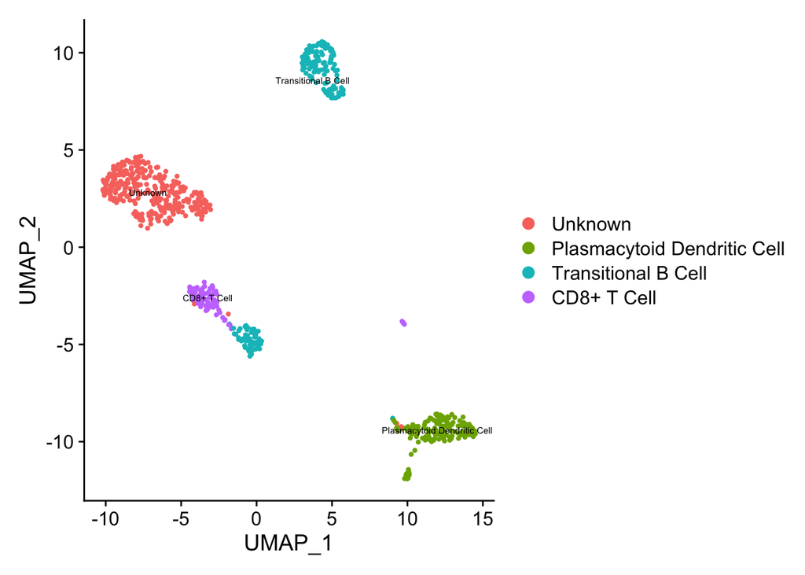

[output not shown]

```r
plot_umap(two_band_low$data,two_band_low_cell_list_name)
```

## Part 4: Clustering Methods

### Overview

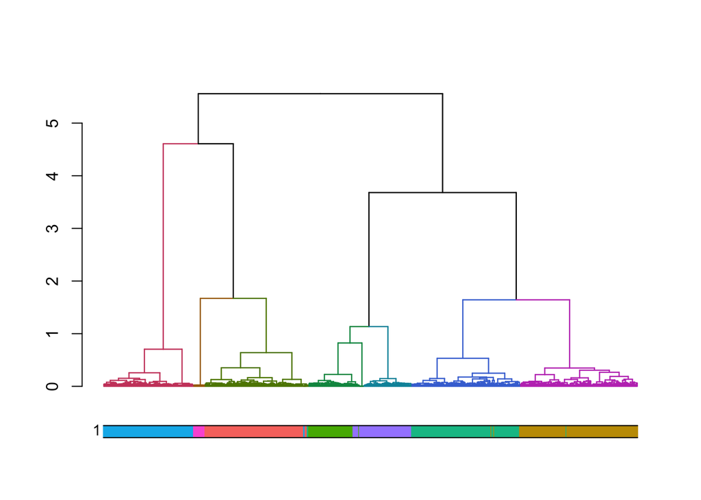

```
## [1] 7
```

```r
# Apply HGC clustering to the dataset
pbmcvv <- FindClusteringTree(two_band_low$data, graph.type = "SNN")
plothgc(pbmcvv)
```

```r
# Input: Seurat Object with HGC clustering
# Output: An HGC plot and the number of clusters
```

In the function above: - We first generate the clustering tree using `FindClusteringTree` with an SNN (Shared Nearest Neighbor) graph type. - We then plot the dendrogram with the `HGC.PlotDendrogram` function, which shows the hierarchical structure of clusters, and the cluster labels are shown on the plot. - The function returns the number of clusters found by the HGC method.

```r
# Convert Seurat object to SingleCellExperiment object
sce = as.SingleCellExperiment(pbmc)
rowData(sce)$feature_symbol <- rownames(sce)  # Set feature names in the row data
sce@assays@data$counts = as.matrix(sce@assays@data$counts)  # Use counts data
sce@assays@data$logcounts = as.matrix(result_2band$low)  # Use log-transformed data

# Apply SC3 clustering with k clusters
k = 3  # Can be adjusted depending on the desired number of clusters
sce <- sc3(sce, ks = k, biology = TRUE)
```

```
## Setting SC3 parameters...
```

```
## Calculating distances between the cells...
```

```
## Performing transformations and calculating eigenvectors...
```

```
## Performing k-means clustering...
```

```
## Calculating consensus matrix...
```

```
## Calculating biology...
```

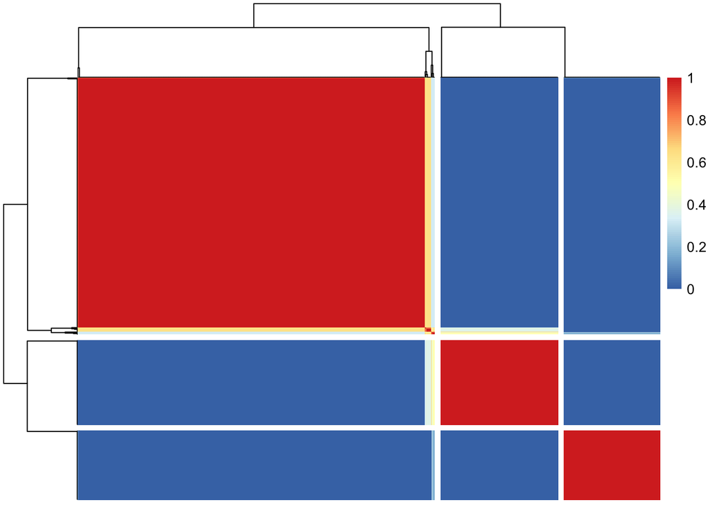

```r
# Plot the consensus matrix
sc3_plot_consensus(sce, k = 3)
```

In this section: - We convert the Seurat object to a `SingleCellExperiment` object (`sce`) and assign the appropriate data. - The `sc3` function is used to perform consensus clustering with `k` clusters, where `k` can be adjusted based on the data and the desired number of clusters. - Finally, we visualize the consensus matrix using `sc3_plot_consensus`, which provides insight into how stable the clusters are.

### Part 5: Evaluation Metrics

#### Calculating ARI and NMI (Adjusted Rand Index & Normalized Mutual Information)

```r
orginal<-main_function(working_matrix,pbmc,working_matrix,"orginial","na")
```

```
## When using repel, set xnudge and ynudge to 0 for optimal results
```

```
## PC_ 1
## Positive:  RPS29, LTB, RPS27, TRAC, RPS6, CD3D, RPS18, IL32, TRBC2, MALAT1
##     RPS12, IL7R, CD3G, LDHB, EEF1A1, CD27, CD7, RPS2, NOSIP, TRBC1
##     CCR7, TCF7, LAT, CD2, CD69, LEF1, CD6, CD247, FCMR, SPOCK2
## Negative:  CST3, CSTA, LYZ, FCN1, LST1, S100A9, LGALS1, TYROBP, MNDA, AIF1
##     FTL, GRN, CTSS, TYMP, S100A8, SERPINA1, SPI1, FGL2, PSAP, S100A12
##     VCAN, FCER1G, MS4A6A, FTH1, AC020656.1, LGALS2, CLEC7A, CD68, CFD, AP1S2
## PC_ 2
## Positive:  NKG7, GZMA, PRF1, CTSW, CST7, GNLY, KLRD1, KLRF1, HCST, GZMM
##     SPON2, KLRB1, TRDC, HOPX, CD7, MATK, IL2RB, GZMB, FGFBP2, CD247
##     CLIC3, CCL4, S1PR5, CMC1, SAMD3, ITGB2, CCL5, PFN1, GZMH, TTC38
## Negative:  CD79A, IGHM, MS4A1, CD79B, HLA-DRA, HLA-DRB1, IGHD, HLA-DQB1, IGKC, HLA-DQA1
##     TCL1A, LINC00926, HLA-DPB1, BANK1, HLA-DPA1, CD74, FCER2, VPREB3, HLA-DQA2, MEF2C
##     HVCN1, TNFRSF13C, CD22, SPIB, CD24, ARHGAP24, CD37, TSPAN13, HLA-DRB5, HLA-DMB
## PC_ 3
## Positive:  TRAC, CD3D, IL7R, LDHB, RPL34, CD3G, NOSIP, RPS12, LEF1, TCF7
##     IL32, CD27, VIM, MAL, RPLP1, S100A12, CD6, RGCC, VCAN, TRAT1
##     PASK, RPS18, EEF1A1, RPS6, S100A6, IER2, LDLRAP1, CD2, BCL11B, S100A8
## Negative:  CD74, GZMB, CD79B, CD79A, IGHM, HLA-DPA1, MS4A1, HLA-DQA1, HLA-DPB1, KLRF1
##     GNLY, HLA-DQB1, IGKC, HLA-DRB1, SPON2, KLRD1, CLIC3, TCL1A, IGHD, PRF1
##     HLA-DQA2, FGFBP2, NKG7, BANK1, PLAC8, CCL4, CXXC5, TRDC, HLA-DRB5, LINC00926
## PC_ 4
## Positive:  RPS2, EEF1A1, MALAT1, RPL34, TMSB10, RPS6, RPS24, RPLP1, RPS18, RPS27
##     RPS29, RPS12, CD52, JUN, SLC25A6, JUNB, CYBA, IER2, LSP1, MT-CO1
##     CD74, CD37, ITGB2, DUSP1, VIM, IFITM2, S100A4, H3F3B, S100A6, NEAT1
## Negative:  PPBP, PF4, CAVIN2, GNG11, TUBB1, AP001189.1, MPIG6B, CLU, GP9, ACRBP
##     CMTM5, HIST1H2AC, ITGA2B, SPARC, TREML1, TMEM40, PDZK1IP1, CD9, CTTN, AC147651.1
##     MAP3K7CL, DMTN, NRGN, TSC22D1, GAS2L1, MMD, MYL9, F13A1, RNF11, ESAM
## PC_ 5
## Positive:  SCT, TNFRSF21, LILRA4, TPM2, SCN9A, LRRC26, GAS6, PLD4, AC119428.2, IL3RA
##     SERPINF1, DERL3, SCAMP5, CCDC50, ITM2C, DNASE1L3, SLC7A5, RHEX, TUBB6, CLEC4C
##     PPP1R14B, IRF7, MYO1E, LILRB4, PTMS, AC097375.1, TCF4, MAP1A, FCER1A, UGCG
## Negative:  S100A12, S100A8, VCAN, AC020656.1, CD79A, KLRF1, RBP7, S100A9, IGHD, SPON2
##     GNLY, CD14, LINC00926, MS4A1, KLRD1, NCF1, FGR, TRDC, FGFBP2, CYP1B1
##     DUSP1, CCL4, PRF1, LAT2, MYOM2, APLP2, TTC38, FCER2, MNDA, NKG7
```

```
## Modularity Optimizer version 1.3.0 by Ludo Waltman and Nees Jan van Eck
##
## Number of nodes: 747
## Number of edges: 23846
##
## Running Louvain algorithm...
## Maximum modularity in 10 random starts: 0.8811
## Number of communities: 7
## Elapsed time: 0 seconds
```

```r
adjustedRandIndex(two_band_low$data$seurat_clusters,orginal$data$seurat_clusters)
```

```
## [1] 0.85145
```

```r
NMI(orginal$data$seurat_clusters,two_band_low$data$seurat_clusters)
```

```
## [1] 0.7950199
```

## License

This software is distributed under the terms of the GNU General Public License, either Version 2, June 1991 or Version 3, June 2007. For more information, see the LICENSE file.

## Contributions

Feel free to raise issues or submit pull requests to improve this project.

## Contact

For any questions, please contact the project maintainer.